# Dog Breed Predictor Algorithm - Find your inner dog

**Classifying dog breeds from images** is considered exceptionally challenging, because of minimal inter-class variation between certain dog breeds. For instance, *even a human* would have trouble distinguishing between a Brittany and a Welsh Springer Spanieldog.

This algorithm leverages **convolutional neural nets** to predict dog types, and apply them to both dog and human images. Using **transfer learning**, this algorithm achieves stellar predictive performance on dog photos. This allows us to predict the associated dog type of their proud human owners.

In particular, the algorithm accepts a file path to an image and first determines whether the image contains a human, dog, or neither. Then,

- if a dog is detected in the image, return the predicted breed.
- if a human is detected in the image, return the resembling dog breed.
- if neither is detected in the image, provide output that indicates an error.

## Step 0: Import Datasets

We start with downloading the required human and dog datasets. Those datasets are not included in the repo as they are too large in size.

- Download the [dog dataset](https://s3-us-west-1.amazonaws.com/udacity-aind/dog-project/dogImages.zip). Unzip the folder and place it in this project's home directory, at the location `/dog_images`.
- Download the [human dataset](https://s3-us-west-1.amazonaws.com/udacity-aind/dog-project/lfw.zip). Unzip the folder and place it in the home directory, at location `/lfw`.

*Note: when using a Windows machine, it is best to use [7zip](http://www.7-zip.org/) to extract the folder.*

```python
import numpy as np
from glob import glob

# save filenames for human and dog images
human_files = np.array(glob("/data/lfw/*/*"))
dog_files = np.array(glob("/data/dog_images/*/*/*"))

# print number of images in each dataset
print('There are %d total human images.' % len(human_files))
print('There are %d total dog images.' % len(dog_files))
```

```
There are 13233 total human images.
There are 8351 total dog images.
```

## Step 1: Detect Humans

In this section, we use OpenCV's implementation of [Haar feature-based cascade classifiers](http://docs.opencv.org/trunk/d7/d8b/tutorial_py_face_detection.html) to detect human faces in images.

OpenCV provides many pre-trained face detectors, stored as XML files on [github](https://github.com/opencv/opencv/tree/master/data/haarcascades). We have downloaded one of these detectors and stored it in the `haarcascades` directory. In the next code cell, we demonstrate how to use this detector to find human faces in a sample image.

```
Number of faces detected: 1
```

```python
import cv2
import matplotlib.pyplot as plt
%matplotlib inline

# extract pre-trained face detector
face_cascade = cv2.CascadeClassifier('haarcascades/haarcascade_frontalface_alt.xml')

# load color (BGR) image
img = cv2.imread(human_files[0])
# convert BGR image to grayscale
gray = cv2.cvtColor(img, cv2.COLOR_BGR2GRAY)

# find faces in image
faces = face_cascade.detectMultiScale(gray)

# print number of faces detected in the image
print('Number of faces detected:', len(faces))

# get bounding box for each detected face
for (x,y,w,h) in faces:
    # add bounding box to color image
    cv2.rectangle(img,(x,y),(x+w,y+h),(255,0,0),2)

# convert BGR image to RGB for plotting
cv_rgb = cv2.cvtColor(img, cv2.COLOR_BGR2RGB)

# display the image, along with bounding box
plt.imshow(cv_rgb)
plt.show()
```

[output not shown]

### Write a Human Face Detector

We can use this procedure to write a function that returns `True` if a human face is detected in an image and `False` otherwise. This function, aptly named `face_detector`, takes a string-valued file path to an image as input and appears in the code block below.

```python
# returns "True" if face is detected in image stored at img_path
def face_detector(img_path):
    img = cv2.imread(img_path)
    gray = cv2.cvtColor(img, cv2.COLOR_BGR2GRAY)
    faces = face_cascade.detectMultiScale(gray)
    return len(faces) > 0
```

### Assess the Human Face Detector

```python
from tqdm import tqdm

human_files_short = human_files[:100]
dog_files_short = dog_files[:100]

## test the performance of the face_detector algorithm
objects = ['Human', 'Dog']
lists = [human_files_short, dog_files_short]

perf_list = []
for category in lists:
    perf = 0
    for path in category:
        face_detected = face_detector(path)
        if face_detected:
            perf +=1
    perf_list.append(perf)

for i in range(2):
    perf_perc = (perf_list[i]/len(lists[i]))*100
    print('%s faces detected by the algorithm is %.1f percent' % (objects[i], perf_perc))
```

```
Human faces detected by the algorithm is 98.0 percent
Dog faces detected by the algorithm is 17.0 percent
```

**Conclusion:** The performance of the face detector algorithm is not perfect, but acceptable for our preliminary purposes.

## Step 2: Detect Dogs

In this section, we use a [pre-trained model](http://pytorch.org/docs/master/torchvision/models.html) to detect dogs in images.

### Obtain Pre-trained VGG-16 Model

The code cell below downloads the VGG-16 model, along with weights that have been trained on [ImageNet](http://www.image-net.org/), a very large, very popular dataset used for image classification and other vision tasks. ImageNet contains over 10 million URLs, each linking to an image containing an object from one of [1000 categories](https://gist.github.com/yrevar/942d3a0ac09ec9e5eb3a).

```python
import torch
import torchvision.models as models

# define VGG16 model
VGG16 = models.vgg16(pretrained=True)

# check if CUDA is available
use_cuda = torch.cuda.is_available()

# move model to GPU if CUDA is available
if use_cuda:
    VGG16 = VGG16.cuda()
```

```
Downloading: "https://download.pytorch.org/models/vgg16-397923af.pth" to /root/.torch/models/vgg16-397923af.pth
```

Given an image, this pre-trained VGG-16 model returns a prediction (derived from the 1000 possible categories in ImageNet) for the object that is contained in the image.

### Making Predictions with a Pre-trained Model

```python
from PIL import Image
import torchvision.transforms as transforms
import numpy as np

def VGG16_predict(img_path):
    '''
    Use pre-trained VGG-16 model to obtain index corresponding to
    predicted ImageNet class for image at specified path

    Args:
        img_path: path to an image

    Returns:
        Index corresponding to VGG-16 model's prediction
    '''
    ## Load and pre-process an image from the given img_path

    # Load the model from global scope (outside of function definition)
    global VGG16

    # Load image and convert to RGB format
    image = Image.open(img_path).convert('RGB')

    # Pre-processing steps: Resize, CenterCrop, ToTensor, Normalization

    # Note: All pre-trained models expect input images normalized in the same way.
    normalize = transforms.Normalize(mean=[0.485, 0.456, 0.406],
                                     std=[0.229, 0.224, 0.225])

    # Note: VGG16 expects 224-dim square images as input, so we resize each image to fit this mold.
    transform = transforms.Compose(
        [transforms.Resize(256),
         transforms.CenterCrop(224),
         transforms.ToTensor(),
         normalize]
    )

    image = transform(image)

    ## Return the *index* of the predicted class for that image

    # Add the missing batch dimension before passing the image to the model
    image = image.unsqueeze_(0)

    # Compute predicted class on GPU
    if use_cuda:
        VGG16, image = VGG16.cuda(), image.cuda()

    # Forward pass: compute predicted outputs by passing image to the VGG16 model
    output = VGG16(image)

    # Convert output probabilities to predicted class index
    _, pred = torch.max(output, 1)

    # Convert predicted class index to numpy integer format without batch dimension
    pred = int(np.squeeze(pred.cpu().numpy()))

    return pred
```

### Write a Dog Detector

This dog detector returns `True` if a dog is detected in an image (and `False` if not).

```python
### returns "True" if a dog is detected in the image stored at img_path
def dog_detector(img_path):
    pred = VGG16_predict(img_path)

    if pred in range(151,268):
        dog_detected = True
    else:
        dog_detected = False

    return dog_detected
```

### Assess the Dog Detector

```python
from tqdm import tqdm

human_files_short = human_files[:100]
dog_files_short = dog_files[:100]

## test the performance of the dog_detector algorithm
objects = ['Human', 'Dog']
lists = [human_files_short, dog_files_short]

perf_list = []
for category in lists:
    perf = 0
    for path in category:
        dog_detected = dog_detector(path)
        if dog_detected:
            perf +=1
    perf_list.append(perf)

for i in range(2):
    perf_perc = (perf_list[i]/len(lists[i]))*100
    print('%s faces detected by the algorithm is %.1f percent' % (objects[i], perf_perc))
```

```
Human faces detected by the algorithm is 0.0 percent
Dog faces detected by the algorithm is 100.0 percent
```

## Step 3: Create a CNN to Classify Dog Breeds (from Transfer Learning)

Now that we have functions for detecting humans and dogs in images, we need a way to predict breed from images. One way is to create a CNN from scratch for this classification task. Another way is to leverage transfer learning. This will help us to greatly improve our predictive accuracy.

### Pre-process data

```python
import os
import torch
import torchvision.models as models
from torchvision import datasets
from PIL import ImageFile
ImageFile.LOAD_TRUNCATED_IMAGES = True
import torchvision.transforms as transforms
import numpy as np

### write data loaders for training, validation, and test sets

# obtain class names automatically
# note: dog breeds classes are folders in each directory with these names
class_names = [item[4:].replace("_", " ") for item in loaders_transfer['train'].dataset.classes]

# obtain number of classes
total_dog_breeds = len(class_names) # total classes of dog types

## load and transform data using ImageFolder

# define training, test and validation data directories
data_dir = '/data/dog_images/'
train_dir = os.path.join(data_dir, 'train')
valid_dir = os.path.join(data_dir, 'valid')
test_dir = os.path.join(data_dir, 'test')

# specify appropriate transforms:
normalize = transforms.Normalize(mean=[0.485, 0.456, 0.406],
                                 std=[0.229, 0.224, 0.225])

# note: data augmentation for train data
augm_transform = transforms.Compose(
    [transforms.RandomResizedCrop(224),
     transforms.RandomHorizontalFlip(),
     transforms.RandomRotation(45),
     transforms.ToTensor(),
     normalize]
)

# note: no data augmentation for validation and test data
transform = transforms.Compose(
    [transforms.Resize(256),
     transforms.CenterCrop(224),
     transforms.ToTensor(),
     normalize]
)

# create data sets for train, validation and test data
train_data = datasets.ImageFolder(train_dir, transform=augm_transform)
valid_data = datasets.ImageFolder(valid_dir, transform=transform)
test_data = datasets.ImageFolder(test_dir, transform=transform)

# print out some data stats
print('Number training images:', len(train_data))
print('Number validation images:', len(valid_data))
print('Number test images:', len(test_data))

## create data loaders

# define dataloader parameters
batch_size = 20
num_workers = 0

# create data loaders and put them in a dictionary
train_loader = torch.utils.data.DataLoader(train_data,
                                           batch_size=batch_size,
                                           shuffle=True,
                                           num_workers=num_workers)
valid_loader = torch.utils.data.DataLoader(valid_data,
                                           batch_size=batch_size,
                                           shuffle=False,
                                           num_workers=num_workers)
test_loader = torch.utils.data.DataLoader(test_data,
                                          batch_size=batch_size,
                                          shuffle=False,
                                          num_workers=num_workers)

loaders_scratch = {
    'train': train_loader,
    'valid': valid_loader,
    'test': test_loader
}
```

```
Number training images: 6680
Number validation images: 835
Number test images: 836
```

### Model Architecture

```python
import torchvision.models as models
import torch.nn as nn

## specify model architecture

# load the pretrained model from pytorch
model_transfer = models.vgg16(pretrained=True)

# freeze weights of feature extractor part of the network
# note: Gradients will not be calculated through optimizer step, and therefore weights will not be updated
for param in model_transfer.features.parameters():
    param.requires_grad = False

# replace the last layer in the vgg classifier group to fit the number of dog breed classes
n_inputs = model_transfer.classifier[6].in_features
n_outputs = total_dog_breeds # 133 dog breeds
updated_last_layer = nn.Linear(n_inputs,n_outputs)

model_transfer.classifier[6] = updated_last_layer

# print out the model structure
print(model_transfer)

# move model to GPU if available
use_cuda = torch.cuda.is_available()

if use_cuda:
    model_transfer = model_transfer.cuda()
```

```
VGG(
  (features): Sequential(
    (0): Conv2d(3, 64, kernel_size=(3, 3), stride=(1, 1), padding=(1, 1))
    (1): ReLU(inplace)
    (2): Conv2d(64, 64, kernel_size=(3, 3), stride=(1, 1), padding=(1, 1))
    (3): ReLU(inplace)
    (4): MaxPool2d(kernel_size=2, stride=2, padding=0, dilation=1, ceil_mode=False)
    (5): Conv2d(64, 128, kernel_size=(3, 3), stride=(1, 1), padding=(1, 1))
    (6): ReLU(inplace)
    (7): Conv2d(128, 128, kernel_size=(3, 3), stride=(1, 1), padding=(1, 1))
    (8): ReLU(inplace)
    (9): MaxPool2d(kernel_size=2, stride=2, padding=0, dilation=1, ceil_mode=False)
    (10): Conv2d(128, 256, kernel_size=(3, 3), stride=(1, 1), padding=(1, 1))
    (11): ReLU(inplace)
    (12): Conv2d(256, 256, kernel_size=(3, 3), stride=(1, 1), padding=(1, 1))
    (13): ReLU(inplace)
    (14): Conv2d(256, 256, kernel_size=(3, 3), stride=(1, 1), padding=(1, 1))
    (15): ReLU(inplace)
    (16): MaxPool2d(kernel_size=2, stride=2, padding=0, dilation=1, ceil_mode=False)
    (17): Conv2d(256, 512, kernel_size=(3, 3), stride=(1, 1), padding=(1, 1))
    (18): ReLU(inplace)
    (19): Conv2d(512, 512, kernel_size=(3, 3), stride=(1, 1), padding=(1, 1))
    (20): ReLU(inplace)
    (21): Conv2d(512, 512, kernel_size=(3, 3), stride=(1, 1), padding=(1, 1))
    (22): ReLU(inplace)
    (23): MaxPool2d(kernel_size=2, stride=2, padding=0, dilation=1, ceil_mode=False)
    (24): Conv2d(512, 512, kernel_size=(3, 3), stride=(1, 1), padding=(1, 1))
    (25): ReLU(inplace)
    (26): Conv2d(512, 512, kernel_size=(3, 3), stride=(1, 1), padding=(1, 1))
    (27): ReLU(inplace)
    (28): Conv2d(512, 512, kernel_size=(3, 3), stride=(1, 1), padding=(1, 1))
    (29): ReLU(inplace)
    (30): MaxPool2d(kernel_size=2, stride=2, padding=0, dilation=1, ceil_mode=False)
  )
  (classifier): Sequential(
    (0): Linear(in_features=25088, out_features=4096, bias=True)
    (1): ReLU(inplace)
    (2): Dropout(p=0.5)
    (3): Linear(in_features=4096, out_features=4096, bias=True)
    (4): ReLU(inplace)
    (5): Dropout(p=0.5)
    (6): Linear(in_features=4096, out_features=133, bias=True)
  )
)
```

**Strategy explained:** We have used the pre-trained VGG16 model as an excellent feature extractor for image classification tasks through transfer learning. For this given task, we need to replace the last layer in the vgg classifier group to fit the number of dog breed classes.

### Specify Loss Function and Optimizer

```python
import torch.optim as optim

criterion_transfer = nn.CrossEntropyLoss()
optimizer_transfer = optim.SGD(model_transfer.classifier.parameters(), lr=0.001)
```

### Train and Validate the Model

```python
def train(n_epochs, loaders, model, optimizer, criterion, use_cuda, save_path):
    """Returns trained model"""

    # initialise minimum validation loss tracker
    valid_loss_min = np.Inf

    # start loop for deep learning over a number of epochs
    for epoch in range(1,n_epochs+1):

        # monitor training and validation loss
        train_loss = 0.0
        valid_loss = 0.0

        ###################
        # Train the model #
        ###################

        # set to train mode
        model.train()

        for batch_i, (data, target) in enumerate(loaders['train']):
            # move model to GPU if available
            if use_cuda:
                data, target = data.cuda(), target.cuda()
            # zero out gradients of optimised variables
            optimizer.zero_grad()
            # feed forward (compute prediction)
            output = model(data)
            # calculate loss (evaluate loss)
            loss = criterion(output, target)
            # packward pass (compute gradients)
            loss.backward()
            # optimiser step (update parameters)
            optimizer.step()
            # compute average training loss
            train_loss = train_loss + ((1 / (batch_i + 1)) * (loss.data - train_loss))

        ######################
        # Validate the model #
        ######################

        # set to eval mode
        model.eval()

        for batch_i, (data, target) in enumerate(loaders['valid']):
            # move model to GPU if available
            if use_cuda:
                data, target = data.cuda(), target.cuda()
            # feed forward (compute prediction)
            output = model(data)
            # calculate loss (evaluate loss)
            loss = criterion(output, target)
            # compute average validation loss
            valid_loss = valid_loss + ((1 / (batch_i + 1)) * (loss.data - valid_loss))

        # print training/validation stats
        print("Epoch: {} \tTraining loss: {:6f} \tValidation loss: {:6f}".format(epoch, train_loss, valid_loss))

        # save best model: only when validation decreases (i.e. reduce potential for over-fitting)
        if valid_loss < valid_loss_min:
            torch.save(model.state_dict(), save_path)
            print("Saving model.. Validation loss ({:6f} --> {:6f})".format(valid_loss_min, valid_loss))
            valid_loss_min = valid_loss

    # returns trained model
    return model


## train model
train(25, loaders_transfer, model_transfer, optimizer_transfer, criterion_transfer, use_cuda, 'model_tranfer.pt')

## load the model that got the best validation accuracy
model_transfer.load_state_dict(torch.load('model_tranfer.pt'))
```

```
Epoch: 1 	Training loss: 4.567031 	Validation loss: 3.537361
Saving model.. Validation loss (   inf --> 3.537361)
Epoch: 2 	Training loss: 3.507306 	Validation loss: 2.023374
Saving model.. Validation loss (3.537361 --> 2.023374)
Epoch: 3 	Training loss: 2.635853 	Validation loss: 1.263199
Saving model.. Validation loss (2.023374 --> 1.263199)
Epoch: 4 	Training loss: 2.243380 	Validation loss: 0.952231
Saving model.. Validation loss (1.263199 --> 0.952231)
Epoch: 5 	Training loss: 2.004573 	Validation loss: 0.796856
Saving model.. Validation loss (0.952231 --> 0.796856)
Epoch: 6 	Training loss: 1.884278 	Validation loss: 0.721782
Saving model.. Validation loss (0.796856 --> 0.721782)
Epoch: 7 	Training loss: 1.765429 	Validation loss: 0.664784
Saving model.. Validation loss (0.721782 --> 0.664784)
Epoch: 8 	Training loss: 1.703365 	Validation loss: 0.627665
Saving model.. Validation loss (0.664784 --> 0.627665)
Epoch: 9 	Training loss: 1.681192 	Validation loss: 0.582274
Saving model.. Validation loss (0.627665 --> 0.582274)
Epoch: 10 	Training loss: 1.636006 	Validation loss: 0.566809
Saving model.. Validation loss (0.582274 --> 0.566809)
Epoch: 11 	Training loss: 1.561081 	Validation loss: 0.550997
Saving model.. Validation loss (0.566809 --> 0.550997)
Epoch: 12 	Training loss: 1.543572 	Validation loss: 0.528114
Saving model.. Validation loss (0.550997 --> 0.528114)
Epoch: 13 	Training loss: 1.525613 	Validation loss: 0.528627
Epoch: 14 	Training loss: 1.487697 	Validation loss: 0.521229
Saving model.. Validation loss (0.528114 --> 0.521229)
Epoch: 15 	Training loss: 1.499730 	Validation loss: 0.509725
Saving model.. Validation loss (0.521229 --> 0.509725)
Epoch: 16 	Training loss: 1.446130 	Validation loss: 0.490119
Saving model.. Validation loss (0.509725 --> 0.490119)
Epoch: 17 	Training loss: 1.435180 	Validation loss: 0.485905
Saving model.. Validation loss (0.490119 --> 0.485905)
Epoch: 18 	Training loss: 1.412668 	Validation loss: 0.483184
Saving model.. Validation loss (0.485905 --> 0.483184)
Epoch: 19 	Training loss: 1.415687 	Validation loss: 0.474105
Saving model.. Validation loss (0.483184 --> 0.474105)
Epoch: 20 	Training loss: 1.406907 	Validation loss: 0.463435
Saving model.. Validation loss (0.474105 --> 0.463435)
Epoch: 21 	Training loss: 1.381950 	Validation loss: 0.457222
Saving model.. Validation loss (0.463435 --> 0.457222)
Epoch: 22 	Training loss: 1.348991 	Validation loss: 0.459459
Epoch: 23 	Training loss: 1.375644 	Validation loss: 0.446632
Saving model.. Validation loss (0.457222 --> 0.446632)
Epoch: 24 	Training loss: 1.338321 	Validation loss: 0.457649
Epoch: 25 	Training loss: 1.330932 	Validation loss: 0.446658
```

### Test the Model

```python
def test(loaders, model, criterion, use_cuda):
    """Calculates the test loss and accuracy of trained model"""

    # monitor test loss and accuracy
    test_loss = 0.0
    class_correct = list(0.0 for i in range(total_dog_breeds))
    class_total = list(0.0 for i in range(total_dog_breeds))

    ##################
    # Test the model #
    ##################

    # set to eval mode
    model.eval()

    for batch_i, (data, target) in enumerate(loaders['test']):
        # move model to GPU if available
        if use_cuda:
            data, target = data.cuda(), target.cuda()
        # feed forward (compute prediction)
        output = model(data)
        # calculate loss (evaluate loss)
        loss = criterion(output, target)
        # monitor test loss (need to multiply by batch size to get average batch loss; loss.item() is average metric)
        test_loss += loss.item()*data.size(0)
        # change output probabilities to predicted class
        _, pred = torch.max(output, 1)
        # compare predictions to true label
        correct_tensor = pred.eq(target.data.view_as(pred))
        # squeeze tensor output (i.e. lose batch_size dimension)
        correct = np.squeeze(correct_tensor.cpu().numpy())
        # calculate test accuracy for each object class
        for i in range(data.size(0)):
            label = target.data[i]
            class_correct[label] += correct[i].item()
            class_total[label] += 1

    # print average test loss for entire test data set
    test_loss = test_loss/len(test_data)
    print("Test loss: {:.6f}\n".format(test_loss))

    ## print accuracy for the trained model for entire test data set

    # print accuracy by dog breed
    for i in range(total_dog_breeds):
        if class_total[i] > 0:
            print('Test Accuracy of %5s: %2d%% (%2d/%2d)\n' % (
                class_names[i], 100. * class_correct[i] / class_total[i],
                np.sum(class_correct[i]), np.sum(class_total[i])))
        else:
            print('Test Accuracy of %5s: N/A (no training examples)\n' % (
                class_names[i]))

    # print average accuracy across all dog breeds
    print('Test Accuracy (Overall): %2d%% (%2d/%2d)' % (
        100. * np.sum(class_correct) / np.sum(class_total),
        np.sum(class_correct), np.sum(class_total)))


## test model
test(loaders_transfer, model_transfer, criterion_transfer, use_cuda)
```

```
Test loss: 0.496484

Test Accuracy of Affenpinscher: 100% ( 8/ 8)

Test Accuracy of Afghan hound: 75% ( 6/ 8)

Test Accuracy of Airedale terrier: 100% ( 6/ 6)

Test Accuracy of Akita: 75% ( 6/ 8)

Test Accuracy of Alaskan malamute: 100% (10/10)

Test Accuracy of American eskimo dog: 87% ( 7/ 8)

Test Accuracy of American foxhound: 100% ( 7/ 7)

Test Accuracy of American staffordshire terrier: 100% ( 8/ 8)

Test Accuracy of American water spaniel: 75% ( 3/ 4)

Test Accuracy of Anatolian shepherd dog: 100% ( 6/ 6)

Test Accuracy of Australian cattle dog: 88% ( 8/ 9)

Test Accuracy of Australian shepherd: 77% ( 7/ 9)

Test Accuracy of Australian terrier: 83% ( 5/ 6)

Test Accuracy of Basenji: 100% ( 9/ 9)

Test Accuracy of Basset hound: 100% (10/10)

Test Accuracy of Beagle: 12% ( 1/ 8)

Test Accuracy of Bearded collie: 100% ( 8/ 8)

Test Accuracy of Beauceron: 85% ( 6/ 7)

Test Accuracy of Bedlington terrier: 100% ( 6/ 6)

```

[output cut: 214 more lines]

```
Test Accuracy of Silky terrier: 60% ( 3/ 5)

Test Accuracy of Smooth fox terrier: 75% ( 3/ 4)

Test Accuracy of Tibetan mastiff: 66% ( 4/ 6)

Test Accuracy of Welsh springer spaniel: 80% ( 4/ 5)

Test Accuracy of Wirehaired pointing griffon: 66% ( 2/ 3)

Test Accuracy of Xoloitzcuintli: 100% ( 3/ 3)

Test Accuracy of Yorkshire terrier: 75% ( 3/ 4)

Test Accuracy (Overall): 85% (711/836)
```

### Predict Dog Breed with the Model

Write a function that takes an image path as input and returns the dog breed (`Affenpinscher`, `Afghan hound`, etc) that is predicted by your model.

```python
from PIL import Image
import torchvision.transforms as transforms
import numpy as np

def predict_breed_transfer(img_path):
    '''
    Use pre-trained VGG-16 model to obtain index corresponding to
    predicted ImageNet class for image at specified path

    Args:
        img_path: path to an image

    Returns:
        Index corresponding to VGG-16 model's prediction
    '''

    # load the model from global scope (outside of function definition)
    global model_transfer

    # load image and convert to RGB format
    image = Image.open(img_path).convert('RGB')

    ## pre-processing steps: Resize, CenterCrop, ToTensor, Normalization

    # note: All pre-trained models expect input images normalized in the same way.
    normalize = transforms.Normalize(mean=[0.485, 0.456, 0.406],
                                     std=[0.229, 0.224, 0.225])

    # note: VGG16 expects 224-dim square images as input, so we resize each image to fit this mold.
    transform = transforms.Compose(
        [transforms.Resize(256),
         transforms.CenterCrop(224),
         transforms.ToTensor(),
         normalize]
    )

    image = transform(image)

    ## return the *index* of the predicted class for that image

    # add the missing batch dimension before passing the image to the model
    image = image.unsqueeze_(0)

    # compute predicted class on GPU
    if use_cuda:
        model_transfer, image = model_transfer.cuda(), image.cuda()

    # set model to eval mode
    model_transfer.eval()

    # forward pass: compute predicted outputs by passing image to the VGG16 model
    output = model_transfer(image)

    # convert output probabilities to predicted class index
    _, pred = torch.max(output, 1)

    # convert predicted class index to numpy integer format without batch dimension and on cpu
    pred_idx = int(np.squeeze(pred.cpu().numpy()))

    return pred_idx
```

## Step 4: Create the Algorithm

The algorithm accepts a file path to an image and first determines whether the image contains a human, dog, or neither. Then,

- if a **dog** is detected in the image, return the predicted breed.
- if a **human** is detected in the image, return the resembling dog breed.
- if **neither** is detected in the image, provide output that indicates an error.

```python
def run_app(img_path):
    ## handle cases for a human face, dog, and neither
    if dog_detector(img_path):
        # first print: human, dog or neither
        print('You are an alpha dog!')
        # show image
        img = Image.open(img_path)
        plt.imshow(img)
        plt.show()
        # second print: predicted dog type
        pred = class_names[predict_breed_transfer(img_path)] # obtain converted dog breed class from idx
        print('And you look like you are a %s.' % pred)
    else:
        if face_detector(img_path):
            # first print: Human, dog or neither
            print('You are human after all!')
            # show image
            img = Image.open(img_path)
            plt.imshow(img)
            plt.show()
            # second print: predicted dog type
            pred = class_names[predict_breed_transfer(img_path)]
            print('And it looks like you are a %s.' % pred)
            # show example of predicted dog type
            class_names_full = loaders_transfer['train'].dataset.classes
            pred_dir = os.path.join('/data/dog_images/train/', class_names_full[predict_breed_transfer(img_path)])
            random_filename = random.choice(os.listdir(pred_dir))
            img = Image.open(os.path.join(pred_dir,random_filename))
            plt.imshow(img)
            plt.show()
            print('Do you see the resemblance?')

        else:
            # first print: Human, dog or neither
            print('No human, no dog!')
            # show image
            img = Image.open(img_path)
            plt.imshow(img)
            plt.show()
```

```
You are an alpha dog!
```

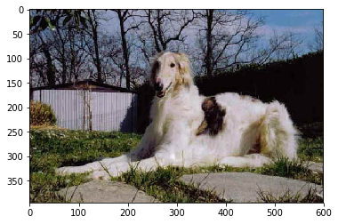

```
And you look like you are a Borzoi.
You are human after all!
```

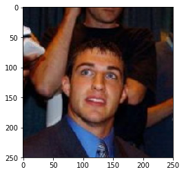

```
And it looks like you are a Ibizan hound.
```

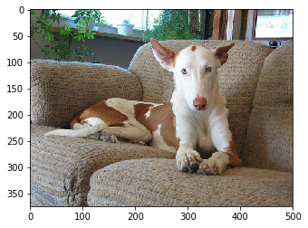

```
Do you see the resemblance?
```

```python
## play around with the app by feeding it random photos from the dog and human datasets
import random

run_app(dog_files[random.randint(0, len(dog_files))])
run_app(human_files[random.randint(0, len(human_files))])
```

## Conclusion and next steps

In terms of next steps, we can explore many more avenues to incrementally improve performance even more.

- Take the model to the cloud and train the model for more epochs.
- Explore other model architectures can help to get even better predictive performance for dog breed classification.
- Leverage more sophisticated data augmentation techniques to reduce the potential for over-fitting.
- Rely on more balanced data to improve overall predictive performance, and for those breeds where the model does not perform well. As some breeds have very few data points, the training data is not perfectly balanced.